# Domestic Violence Against Women in Peru

Findings from the 2018 Demographic and Health Survey

Alice osmaston

2023-01-16

# 1 Age distribution of abuse victims

The following analyses focus on women who were selected for the domestic violence module of the DHS survey and were ever-married (defined as currently or previously living with a partner). Where multiple women per household qualified, only one per household was asked. Therefore, out of the total 23,888 women surveyed (ages 15 to 49), 17,707 were asked the domestic violence questions, and of those, 9,786 (55.3%) were victims of some form of manipulative control, or emotional or physical violence.

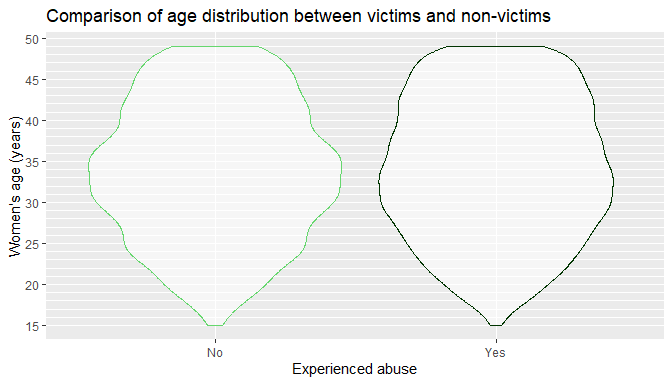

Figure 1. Age distribution of women who reported experiencing abuse compared with those who did not.

Figure 1 shows the age distribution of domestic violence victims compared to non-victims. The mean age of victims was 33.81 years, with a standard deviation of 8.26, versus 34.02 years and 8.42 for those who did not report any form of abuse.

# 2 From whom victims of abuse seek help

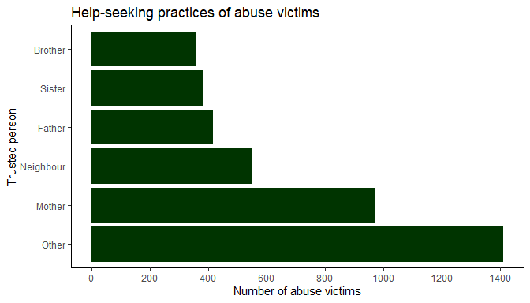

Figure 2. Help-seeking practices of abuse victims

Figure 2 shows the 5 most popular people from whom victims of abuse keep help. The most common single source of help is the victim’s mother; 973 people reported doing so. ‘Other’ accounts for a largo proportion of the help-seeking behaviour and this category consists of 8 other potential sources of help, the highest of which is a female relative, whom 313 people reported. Groups included in the ‘other’ category are as follows:

- Husband
- Daughter
- Son
- Own family
- Step-mother
- Step-father
- Female friend
- Male friend

# 3 Subset analysis of physical abuse victims

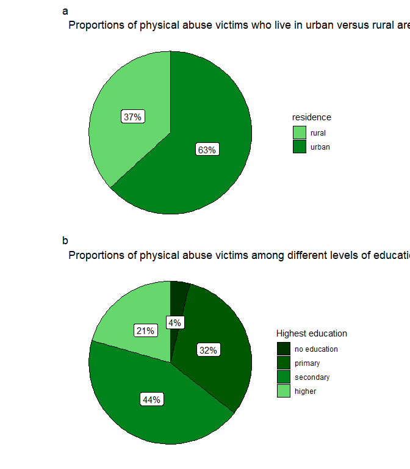

Figure 3. Pie charts to show distribution of physical abuse victims across education levels and urbanicity.

Figure 3a shows that while (67%) of Peru’s population live in urban areas (total23,888), the percentage of physical abuse against people living in urban areas is slightly lower, at 63%.

Figure 3b shows that the lowest education level corresponds to the lowest proportion of physical abuse victims, while those who reached secondary education account for the largest proportion.

# 4 Median age of victims of abuse by wealth category

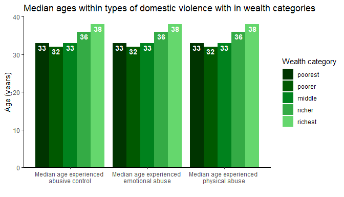

Figure 4. Median ages within types of domestic violence with in wealth categories

Figure 4 shows the median age of abuse victims for each of the three types of abuse measired in this survey, grouped by the 5 wealth categories. Out of all the women who were asked the domestic violence module questions, 51.6% suffered abusive control, 23.6% suffered emotional abuse and 23.6% suffered physical abuse. Across all three types of abuse, there is a general trend that women in the wealthier categories begin experiencing domestic violence later in life (except for the second poorest category).